# Data Science for sustainability : Economic and Social Satisfaction of Young Italian Graduates

30-7-2020

### Abstract

The analysis conducted aims to represent the level of satisfaction of young Italian graduates on an economic and social level, on the hypothesis that this may be to some extent associated with the “brain drain” phenomenon.

### Introduction

The phenomenon known as “brain drain” is a very sensitive and central issue in the socio-political discussion in Italy. It refers to a country’s loss of skilled human capital and the simultaneous lack of *brain circulation*. As Alessandro Rosina, Professor of Demography and Social Statistics of the Catholic University of Milan explains, the phenomenon is entirely consistent with the development processes of this century. If on one hand there is the possibility of traveling with limited times and costs, on the other the attitude of the new generations has also changed, increasingly globalized, more inclined to move, to interact and deal with different cultures and realities. As the scholar points out, *“It is wrong to try to cage one’s talents. On the other hand, however, even one-way flight is not desirable, because it impoverishes the place of departure.”* Using the words of E. Durkheim, we could to define the phenomenon as a social fact [^1] characteristic of this century; the problem in Italy is the unidirectional process of the phenomenon in question: *“The optimal condition is instead circulation, that is, the possibility of being able to go, but with the same ease being able to do the reverse path and return. The problem of Italy are not the valuable many who leave, but the few who go the opposite way. This impoverishes our country and causes it to enter a negative spiral.”* [^2] Italy, therefore, is facing a double challenge: on one hand, the worrying increase in the level of qualification of the human capital leaving the country (high-school and graduates) with consequent damage to national competitiveness. On the other hand, there is Italy’s scarce ability to attract skilled human capital from the rest of the world.

### Chapter 1

#### 1.1 Objective definition : social and economic analysis of young Italian graduates satisfaction

On the basis of the socio-demographic context described in the introduction of this article, the investigation illustrates the level of economic and social satisfaction of young Italian graduates between 20 and 34 years old, on the hypothesis that this may, to some extent, be associated with the *brain drain* phenomenon. The data considered are taken from the “Multipurpose Survey on Families: Aspects of Daily Life”. This is a sample survey proposed by ISTAT (starting from 1993 and carried out every year) aimed at detecting fundamental information relating to the daily life of individuals and families. The information collected describe the habits of citizens and the problems they face every day and whether they are satisfied with the functioning of those public utility services that should contribute to improving the quality of life. In the case in question, the data refer to the year 2018 and the variables relating to the satisfaction of one’s economic and social life are taken into consideration. The proposed analysis, therefore, aims to study the profile of young Italian graduates (by region) on the basis of their level of satisfaction in respect to their economic and social sustainability.

#### 1.2 Dataframe definition in accordance with the study objective

The **giov** variable reduces the size of the observations of the dataset AVQ_Microdati_2018 to young Italian high-school diploma and graduates aged between 20-34 years old, also filtering the main active variables considered for this project (aspects of economic satisfaction 317,689,690 and aspects of social satisfaction 319,320,321,453). The variables **giov_laur_ita** and **giov_dipl_ita** are also defined as young graduates (the first) and young high-school diploma (the second), useful for analyzes to compare the level of economic and social satisfaction between graduates and high-school diploma. The analysis conducted in the first surveys (monovariate and bivariate) aims at comparing the economic and social situation divided between graduates and high-school diploma, to have a comparison of the trend between the two categories. Lastly, the study is carried on only with the category of graduates, to illustrate the level of satisfaction proposed by the analysis objective. Following the surveys on young emigrants (eg. Il Fatto Quotidiano [^3]), there are more graduates than high-school diploma to leave the country; this comparison, therefore, could return interesting data on the trend of one or the other category.

```r
# Define young italian graduates (also with diploma)
giov<- AVQ_Microdati_2018[AVQ_Microdati_2018$REGMF >= 10 &
                                     AVQ_Microdati_2018$REGMF <= 200 &
                                     AVQ_Microdati_2018$ETAMi >= 8 &
                                     AVQ_Microdati_2018$ETAMi <= 9 &
                                     AVQ_Microdati_2018$ISTRMi >= 1 &
                                     AVQ_Microdati_2018$ISTRMi <= 7 &
                                     AVQ_Microdati_2018$CITTMi == 1
                                   ,c(6,7,11,20,21,317,689:690,319:321,453)]

# Transform variables in factors
for (i in 1:length(giov))
  giov[[i]]<-as.factor(giov[[i]])

# Label all illustrative variables
levels(giov$ETAMi) <-c("20-24", "25-34")
levels(giov$SESSO) <-c("male", "female")
levels(giov$ISTRMi) <-c("graduates","diploma")
levels(giov$REGMF) <-c("piemonte","valleAosta","lombardia","trentino",
                                "veneto","friuli","liguria","emiliaRomagna","toscana",
                                "umbria","marche","lazio","abruzzo","molise","campania",
                                "puglia","basilicata","calabria","sicilia","sardegna")
levels(giov$RIPMF)<-c("north-west","north-east","center", "south", "islands",
                               "not avail")

# Label all active variables
levels(giov$SITEC)<-c("very", "enough", "little", "not at all")
giov$SITEC<-factor(giov$SITEC, order=TRUE,
                            levels=c("not at all", "little", "enough", "very" ))
levels(giov$SITE)<-c("very improved", "little better",
                               "almost unchanged", "little worse", "much worse" )
giov$SITE<-factor(giov$SITE, order=TRUE,
                           levels=c("much worse", "little worse",
                                     "almost unchanged", "little better",
                                     "very improved" ))
levels(giov$RISEC)<-c("excellent", "adequate", "poor", "absolutely insufficient" )
giov$RISEC<-factor(giov$RISEC, order=TRUE,
                            levels=c("absolutely insufficient", "scarce",
                                      "adequate", "excellent" ))
levels(giov$RELFAM)<-c("very", "enough", "little", "not at all" )
giov$RELFAM<-factor(giov$RELFAM, order=TRUE,
                            levels=c("not at all", "little", "enough", "a lot"))
levels(giov$RELAM)<-c("very", "enough", "little", "not at all" )
giov$RELAM<-factor(giov$RELAM, order=TRUE,
                            levels=c("not at all", "a little", "enough", "a lot" ))
levels(giov$TEMLIB)<-c("very", "enough", "little", "not at all" )
giov$TEMLIB<-factor(giov$TEMLIB, order=TRUE,
                            levels=c("not at all", "a little", "enough", "a lot" ))
levels(giov$FUTUASP)<-c("it will improve", "it will stay the same", "it will get worse", "I don't know" )
giov$FUTUASP<-factor(giov$FUTUASP, order=TRUE,
                            levels=c("I don't know", "it will get worse",
                                      "will remain the same", "will improve" ))
```

```r
# Define young graduates (diplomati)
giov_dipl_ita <- giov[giov$ISTRMi != "graduate",1:12]
# Define young graduates (laureati)
giov_laur_ita <- giov[giov$ISTRMi != "diploma",1:12]
```

#### 1.3 Descriptive analysis

Following the dataset definition, I check the structure of the new dataframe, the labeling and ordering of the ordinal variables; finally I trace the distribution of the frequencies.

```r
str(giov)
```

```
## 'data.frame':    5012 obs. of  12 variables:
##  $ ETAMi  : Factor w/ 2 levels "20-24","25-34": 1 2 1 1 2 2 2 2 2 1 ...
##  $ SESSO  : Factor w/ 2 levels "male","female": 1 2 1 2 2 1 2 2 2 2 ...
##  $ ISTRMi : Factor w/ 2 levels "graduates","diploma": 2 1 2 1 1 1 2 2 1 2 ...
##  $ REGMF  : Factor w/ 20 levels "piemonte","valleAosta",..: 7 7 7 7 7 9 9 9 9 15 ...
##  $ RIPMF  : Factor w/ 6 levels "north-west","north-east",..: 1 1 1 1 1 3 3 3 3 4 ...
##  $ SITEC  : Ord.factor w/ 4 levels "not at all"<"little"<..: 2 3 3 3 1 2 2 2 2 3 ...
##  $ SITE   : Ord.factor w/ 5 levels "much worse"<"little worse"<..: 3 3 3 3 3 3 2 2 3 3 ...
##  $ RISEC  : Ord.factor w/ 4 levels "absolutely insufficient"<..: 3 3 3 3 3 3 NA NA 3 3 ...
##  $ RELFAM : Ord.factor w/ 4 levels "not at all"<"little"<..: 2 3 NA NA 3 3 3 3 NA 3 ...
##  $ RELAM  : Ord.factor w/ 4 levels "not at all"<"a little"<..: NA 3 3 3 3 NA NA 3 NA 3 ...
##  $ TEMLIB : Ord.factor w/ 4 levels "not at all"<"a little"<..: NA NA 3 3 3 NA 3 3 NA 3 ...
##  $ FUTUASP: Ord.factor w/ 4 levels "I don't know"<..: NA NA NA NA 1 NA NA NA NA NA ...
```

```r
summary(giov)
```

```
##    ETAMi         SESSO            ISTRMi           REGMF             RIPMF
##  20-24:1664   male  :2481   graduates:1538   campania : 427   north-west:1021
##  25-34:3348   female:2531   diploma  :3474   lombardia: 419   north-east:1048
##                                              trentino : 341   center    : 867
##                                              puglia   : 324   south     :1590
##                                              sicilia  : 314   islands   : 486
##                                              piemonte : 306   not avail :   0
##                                              (Other)  :2881
##         SITEC                    SITE                          RISEC
##  not at all: 578   much worse      : 243   absolutely insufficient: 209
##  little    :1682   little worse    : 983   scarce                 :   0
##  enough    :2415   almost unchanged:3097   adequate               :3194
##  very      : 272   little better   : 589   excellent              :  73
##  NA's      :  65   very improved   :  69   NA's                   :1536
##                    NA's            :  31
##
##         RELFAM            RELAM             TEMLIB
##  not at all:  55   not at all:  68   not at all: 167
##  little    : 266   a little  :   0   a little  :   0
##  enough    :2624   enough    :2795   enough    :2794
##  a lot     :   0   a lot     :   0   a lot     :   0
##  NA's      :2067   NA's      :2149   NA's      :2051
##
##
##                  FUTUASP
##  I don't know        : 933
##  it will get worse   : 150
##  will remain the same:   0
##  will improve        :   0
##  NA's                :3929
##
##
```

In relation to the 2018 sample survey proposed by ISTAT, the new dataset is made up of 5012 young people aged 20-34, of which 1538 graduates and 3474 with high-school diploma. Among the variables, 5 illustrative variables were considered (in order “age”, “sex”, “education”, “region of residence”, “geographical location”) and 7 active variables, divided into 3 for the category **economic satisfaction** (in order *“Satisfaction with the economic situation in the last 12 months”*, *“Evaluation of the economic situation of the family compared to that of a year ago”*, *“Overall economic resources of the family in the last 12 months”*) and 4 for the category **social satisfaction** (in order *“Satisfaction with family relationships in the last 12 months”*, *“Satisfaction with relationships with friends in the last 12 months”*, *“Leisure time satisfaction in the last 12 months”*, *“Personal situation expectation in the next 5 years”*)

### Chapter 2: Univariate analysis

In this section are performed the main univariate analysis of the chosen variables under examination. In a first analysis, the results are reported with reference to the illustrative variables; then it is proceeded with the analysis of the active variables

#### Univariate analysis of illustrative variables

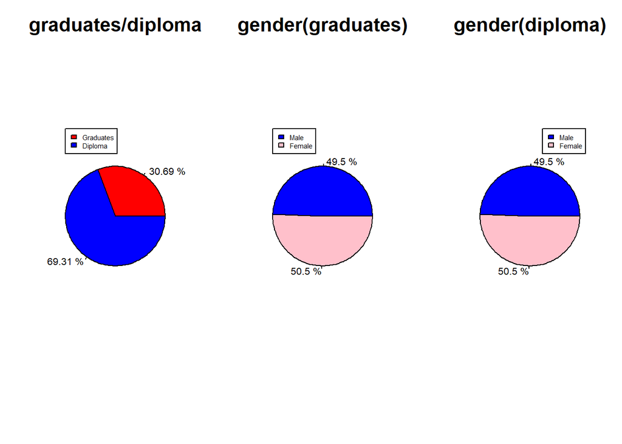

```r
par(mfcol=c(1,3))
pct<-round(table(na.omit(giov$ISTRMi))/length(giov$ISTRMi)*100,2)
et<-paste("",pct,"%",sep=" ")
pie(pct,labels=et,main="graduates/diploma",
    cex.main=2.0,  col=c("red","blue"))
legend(
  x=-0.8,y=1.4,
  legend = c("Graduates","Diploma"),
  fill = c("red","blue"),
  bg = "white",cex=0.7
)
pct1<-round(table(na.omit(giov[giov$ISTRMi != "diplomato",1:12]$SESSO))/length(giov[giov$ISTRMi != "diplomato",1:12]$SESSO)*100,2)
et<-paste("",pct1,"%",sep=" ")
pie(pct1,labels=et,main="gender(graduates)",
    cex.main=2.0,  col=c("blue","pink"))
legend(
  x=-0.8,y=1.4,
  legend = c("Male","Female"),
  fill = c("blue","pink"),
  bg = "white",cex=0.7
)
pct2<-round(table(na.omit(giov[giov$ISTRMi != "laureato",1:12]$SESSO))/length(giov[giov$ISTRMi != "laureato",1:12]$SESSO)*100,2)
et<-paste("",pct2,"%",sep=" ")
pie(pct2,labels=et,main="gender(diploma)",
    cex.main=2.0,  col=c("blue","pink"))
legend(x=+0.2,y=1.4,
  legend = c("Male","Female"),
  fill = c("blue","pink"),
  bg = "white",cex=0.7
)
```

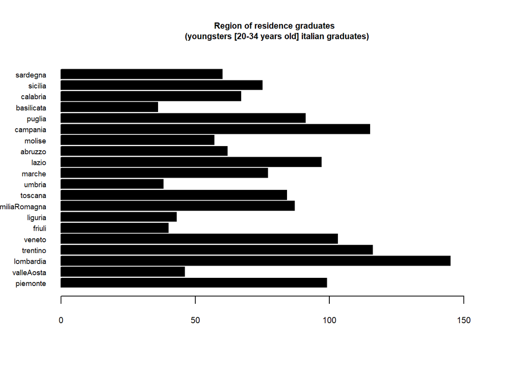

```r
barplot(table(giov_laur_ita$REGMF), main="Region of residence graduates \n (youngsters [20-34 years old] italian graduates)", col=c("black"),cex.names=0.6, cex.axis=0.7, cex.main=0.7, las=1, xlim=c(0,160), horiz=T)
```

The graph shows that there is a higher prevalence of graduates in Lombardia and a good incidence also in the regions of Trentino and Campania; low incidence, however, in the Basilicata region.

#### 2.2 Univariate category analysis **economic satisfaction**

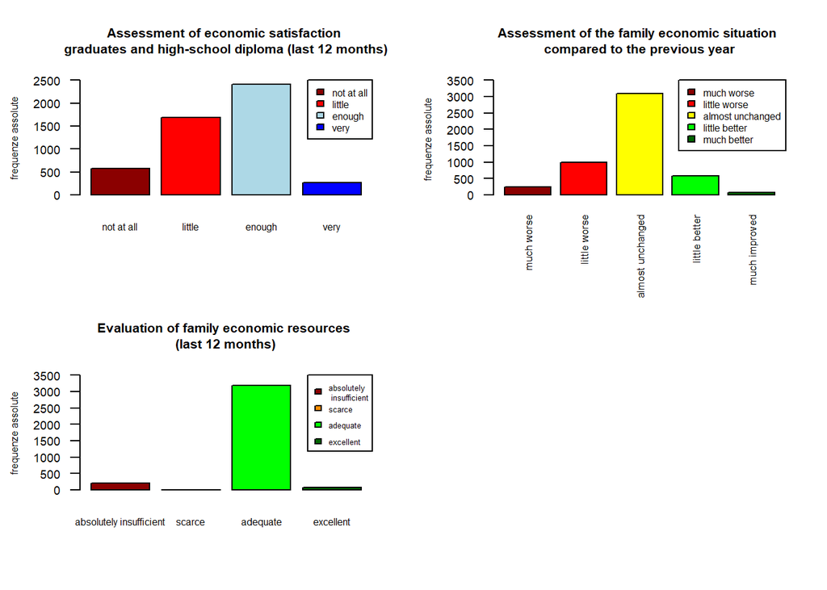

```r
par(mfrow= c(2,2))
freq<-table(giov$SITEC)
barplot(freq,main="Assessment of economic satisfaction \n graduates and high-school diploma (last 12 months) ",
        legend=TRUE,args.legend=list(cex=0.60,x="topright"),adj=0.5,
        ylab="frequenze assolute",col=c("darkred", "red", "lightblue", "blue"),
        cex.main=0.8, las=1,cex.names = 0.6,cex.axis=0.7,cex.lab=0.6, ylim=c(0,2500), horiz=FALSE)

freq1<-table(giov$SITE)
barplot(freq1,names.arg = c("much worse", "little worse", "almost unchanged", "little better","much improved" ) ,
        main="Assessment of the family economic situation \n compared to the previous year ",
        cex.main=0.8,las=2,ylab="frequenze assolute ",
        legend.text=c("much worse", "little worse", "almost unchanged", "little better", "much better" ),
        args.legend=list(cex=0.60,x="topright"), cex.names = 0.65,col=c("darkred", "red", "yellow", "green", "darkgreen"),ylim=c(0,3500),cex.lab=0.6,cex.axis=0.7, horiz=FALSE)

freq2<-table(giov$RISEC)
barplot(freq2, names.arg = c("absolutely insufficient", "scarce", "adequate", "excellent" ),
        main="Evaluation of family economic resources \n (last 12 months) ",cex.main=0.8,
        legend.text=c("absolutely \n insufficient", "scarce", "adequate", "excellent"),
        args.legend=list(cex=0.50,x="topright"), ylab="frequenze assolute",col=c("darkred", "darkorange", "green", "darkgreen"), las=1.5,cex.names = 0.6,las=1,cex.axis=0.7,cex.lab=0.6, ylim=c(0,3500), horiz=FALSE)
```

It is clear that young people are mostly quite satisfied with their economic situation (with reference to the last twelve months); however, there is a good part of dissatisfaction among the little and not at all satisfied. As regards, however, the assessment of their family economic situation compared to the previous year, the same is almost unchanged for the majority of young Italian graduates. With reference, then, to the assessment of family economic resources (relating to the last 12 months), the young people in question mainly believed that they were adequate to their status.

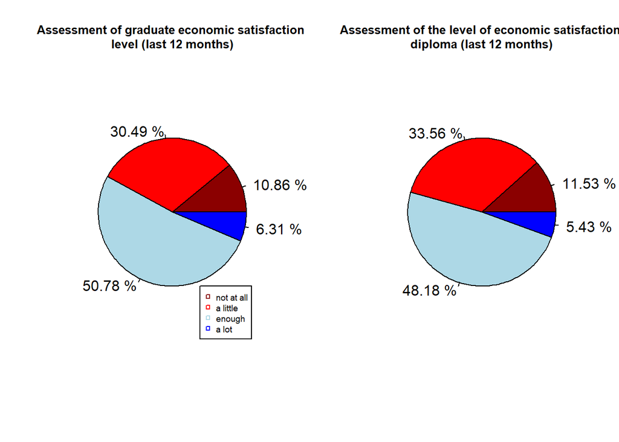

```r
par(mfcol=c(1,2))
pct<-round(table(na.omit(giov_laur_ita$SITEC))/length(giov_laur_ita$FUTUASP)*100,2)
et<-paste("",pct,"%",sep=" ")
pie(pct,labels=et,
    main="Assessment of graduate economic satisfaction \n level (last 12 months) ",
    cex.main=0.8,
    col=c("darkred", "red", "lightblue", "blue"))
legend(x=0.3,y=-0.8, legend=c("not at all", "a little", "enough", "a lot"),pch=22,border="grey", col=c("darkred", "red", "lightblue", "blue"),cex=0.6)

pct1<-round(table(na.omit(giov_dipl_ita$SITEC))/length(giov_dipl_ita$FUTUASP)*100,2)
et<-paste("",pct1,"%",sep=" ")
pie(pct1,labels=et,
    main="Assessment of the level of economic satisfaction \n diploma (last 12 months) ",
    cex.main=0.8,
    col=c("darkred", "red", "lightblue", "blue"))
```

#### 2.3 Univariate analysis category **social satisfaction**

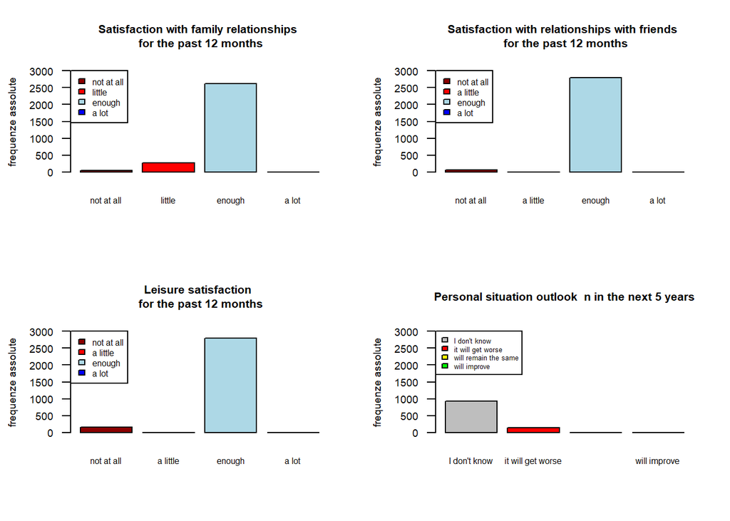

```r
par(mfrow= c(2,2))
barplot(table(giov$RELFAM), main="Satisfaction with family relationships \n for the past 12 months",
        legend=TRUE,args.legend=list(cex=0.60,x="topleft"),
        ylab="frequenze assolute",col=c("darkred", "red", "lightblue", "blue"),adj=0.5,
        cex.main=0.8, las=1,cex.names = 0.6,cex.axis=0.7,cex.lab=0.7,ylim=c(0,3000), horiz=FALSE)

barplot(table(giov$RELAM), main="Satisfaction with relationships with friends \n for the past 12 months" ,
        legend=TRUE,args.legend=list(cex=0.60,x="topleft"),
        ylab="frequenze assolute",col=c("darkred", "red", "lightblue", "blue"),
       cex.main=0.8, las=1,cex.names = 0.6,cex.axis=0.7,cex.lab=0.7,ylim=c(0,3000), horiz=FALSE)

barplot(table(giov$TEMLIB), main="Leisure satisfaction \n for the past 12 months" ,
        legend=TRUE,args.legend=list(cex=0.60,x="topleft"),
        ylab="frequenze assolute",col=c("darkred", "red", "lightblue", "blue"),
        cex.main=0.8, las=1,cex.names = 0.6,cex.axis=0.7,cex.lab=0.7,ylim=c(0,3000), horiz=FALSE)

barplot(table(giov$FUTUASP), main="Personal situation outlook \ n in the next 5 years",
        legend=TRUE,args.legend=list(cex=0.50,x="topleft"),
        ylab="frequenze assolute",col=c("gray","red","yellow","green"),
        cex.main=0.8, las=1.5,cex.names = 0.6 ,cex.axis=0.7,cex.lab=0.7,ylim=c(0,3000), horiz=FALSE)
```

### Chapter 3: Bivariate analysis

In this section will be illustrated the main bivariate analysis. To simplify the representation according to the analysis objective, the dataset has been resized by categorizing the active variables through (mainly) two levels: *“very satisfied”* and *“quite satisfied”* are categorized into **“satisfied”** , while the *“not satisfied”* and *“not satisfied at all”* become **“dissatisfied”**. The variable SITE (“Evaluation of the economic situation of the family compared to that of a year ago”) has been categorized into 3 levels: from *“much improved”, “little improved”, “almost unchanged”, “little worse”* and *“much worse”* a *“satisfied”, “average satisfied”, “dissatisfied”*. Finally, the variable FUTUASP (“Expectation of personal situation in the next 5 years”) remained unchanged.

```r
summary(giov_categ)
```

```
##    ETAMi         SESSO           ISTRMi           REGMF
##  20-24:1664   male  :2481   graduate:1538   campania : 427
##  25-34:3348   female:2531   diploma :3474   lombardia: 419
##                                             trentino : 341
##                                             puglia   : 324
##                                             sicilia  : 314
##                                             piemonte : 306
##                                             (Other)  :2881
##            RIPMF            SITEC               SITE            RISEC
##  north-west   :1021   nonSodd_e:2260   nonSodd_e  :1226   nonSodd_e:1715
##  north-east   :1048   Sodd_e   :2687   medioSodd_e:3097   Sodd_e   :3267
##  center       : 867   NA's     :  65   Sodd_e     : 658   NA's     :  30
##  south        :1590                    NA's       :  31
##  islands      : 486
##  not available:   0
##
##        RELFAM           RELAM            TEMLIB                  FUTUASP
##  nonSodd_s: 321   nonSodd_s: 456   nonSodd_s:1234   non so           : 933
##  Sodd_s   :4621   Sodd_s   :4487   Sodd_s   :3707   peggiorera       : 150
##  NA's     :  70   NA's     :  69   NA's     :  71   restera la stessa: 850
##                                                     migliorera       :3010
##                                                     NA's             :  69
##
##
```

As illustrated by the univariate analysis, the prevalence of ordinal characters is more frequent in the central levels (*“fairly satisfied”* and *“not satisfied”*). Although the categorization of the characters reduces the qualitative information about the intensity of the phenomenon, through the categorization the relationship between the degree of satisfaction and the degree of dissatisfaction of the active variables considered is more evident.

#### 3.1 Bivariate analysis

Starting from the **giov_categ** dataset and assuming that there might be a link between the variables of the different macro-areas, the bivariate analysis were carried out in particular between: satisfaction with economic sustainability, satisfaction with social sustainability and socio-demographic data. The analysis in question was performed by proceeding through the following phases:

1. In the first phase it was calculated and printed the empirical and theoretical contingency tables on the screen in order to allow the immediate verification of the independence between the variables under study. Furthermore, the empirical table was plotted by means of a bubbleplot or fourfold.
2. Subsequently it is proceeded to the calculation of the chi-square, which allowed us to verify the independence between the variables when the value of the same is equal to 0. The positive value of the index indicates, instead, a dependence between the two variables compared; dependence (degree of association between variables) which cannot be quantified, as the value of the index is influenced by the sample size. For this reason it was considered appropriate to proceed with the calculation of the Cramer index, which being normalized and purified from the sample size, allows to quantify the degree of association between the variables under study, with a value that varies between 0 and 1 ( V = 0 perfect independence, V = 1 perfect dependence).
3. Finally, in order to analyze between which modalities of the two variables there is a dependence, we resorted to visualization through the mosaicplot, the latter, which has the function of automatically carrying out a statistical test, has allowed us to verify what degree of association exists between the different modalities of the variables under study.
4. The most significant results obtained from the bivariate analysis were analyzed in detail by comparing the levels of economic and social satisfaction individually for young graduates and youngsters with high-school diploma.

#### a) bivariate analysis: satisfaction with economic sustainability and satisfaction with social sustainability

##### i) association between economic satisfaction in the last 12 months and satisfaction with family relationships in the last 12 months

```r
# load library vcd
library(vcd)
giov_categ<-na.omit(giov_categ)

# contingency table
freq_sitec_relfam<-table(giov_categ$RELFAM,giov_categ$SITEC)

# print table
freq_sitec_relfam
```

```
##
##             nonSodd_e Sodd_e
##   nonSodd_s       214    102
##   Sodd_s         2014   2548
```

```r
# define chi-squared
chiq<-chisq.test(freq_sitec_relfam)

#  print theorical contingency table
chiq$expected
```

```
##
##             nonSodd_e    Sodd_e
##   nonSodd_s  144.3313  171.6687
##   Sodd_s    2083.6687 2478.3313
```

```r
# print chi-squared
chiq
```

```
##
##  Pearson's Chi-squared test with Yates' continuity correction
##
## data:  freq_sitec_relfam
## X-squared = 65.244, df = 1, p-value = 6.617e-16
```

```r
# calculate Cramer
ass<-assocstats(freq_sitec_relfam)
# print Cramer
ass$cramer
```

```
## [1] 0.1164871
```

```r
# load library labstatR
library(labstatR)
```

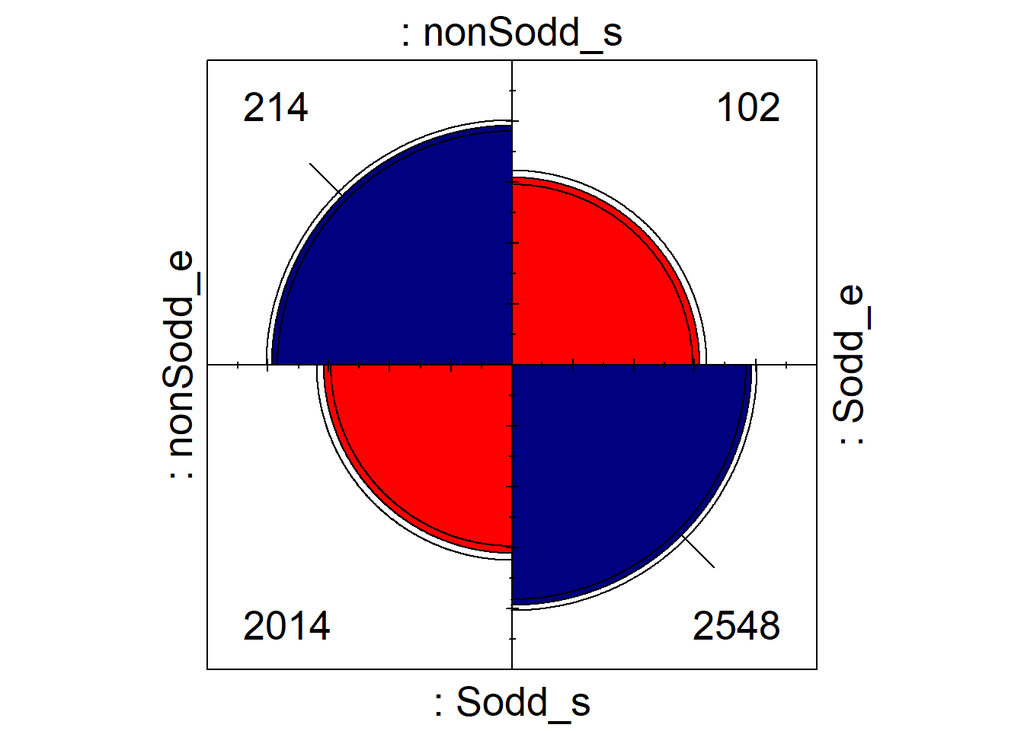

```r
# visualize through fourfold graph the empirical contingency table
fourfold(freq_sitec_relfam)
```

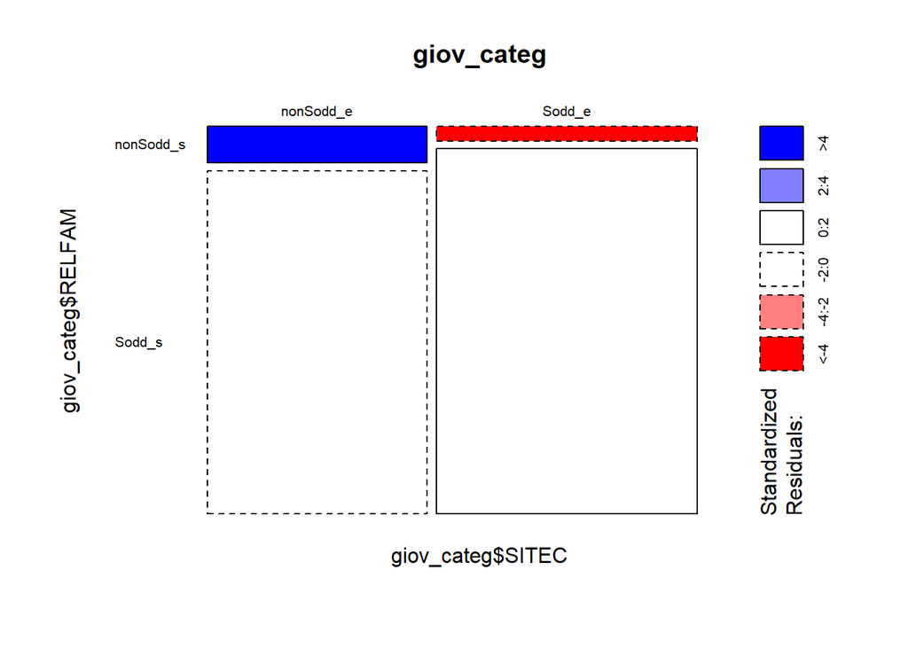

```r
# mosaicoplot SITEC and RELFAM young graduates
mosaicplot(~giov_categ$SITEC+ giov_categ$RELFAM, data=giov_categ,  shade=TRUE, color=TRUE,las=1)
```

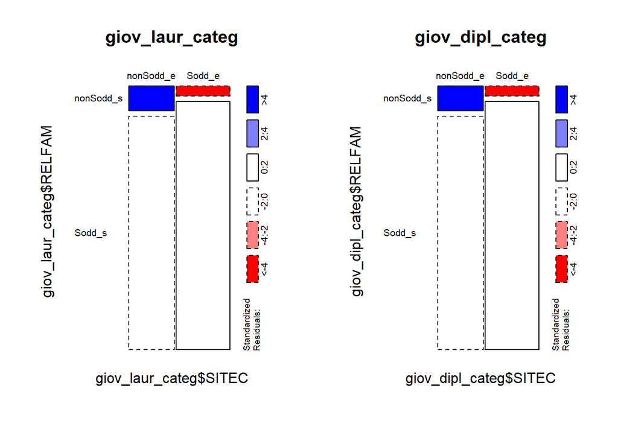

```r
par(mfcol=c(1,2))

# mosaicoplot SITEC and RELFAM young graduates
mosaicplot(~giov_laur_categ$SITEC+ giov_laur_categ$RELFAM, data=giov_laur_categ,  shade=TRUE, color=TRUE,las=1)
# mosaicoplot SITEC and RELFAM young graduates
mosaicplot(~giov_dipl_categ$SITEC+ giov_dipl_categ$RELFAM, data=giov_dipl_categ,  shade=TRUE, color=TRUE,las=1)
```

##### ii) association between family economic evaluation compared with that of the previous year and satisfaction with family relationships in the last 12 months

```r
freq_relfam_site<-table(giov_categ$RELFAM,giov_categ$SITE)

# print contingency table RELFAM and SITE
freq_relfam_site
```

```
##
##             nonSodd_e medioSodd_e Sodd_e
##   nonSodd_s        96         177     43
##   Sodd_s         1103        2851    608
```

```r
# chi-squared
chiq<-chisq.test(freq_relfam_site)

# print theoretical contingency table
chiq$expected
```

```
##
##             nonSodd_e medioSodd_e   Sodd_e
##   nonSodd_s    77.672    196.1558  42.1722
##   Sodd_s     1121.328   2831.8442 608.8278
```

```r
# print chi-squared
chiq
```

```
##
##  Pearson's Chi-squared test
##
## data:  freq_relfam_site
## X-squared = 6.642, df = 2, p-value = 0.03612
```

```r
# calculate Cramer
ass<-assocstats(freq_relfam_site)

# print Cramer
ass$cramer
```

```
## [1] 0.03690018
```

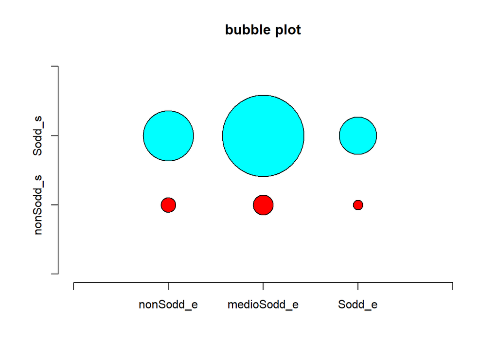

```r
# visualize bubble plot
bubbleplot(freq_relfam_site)
```

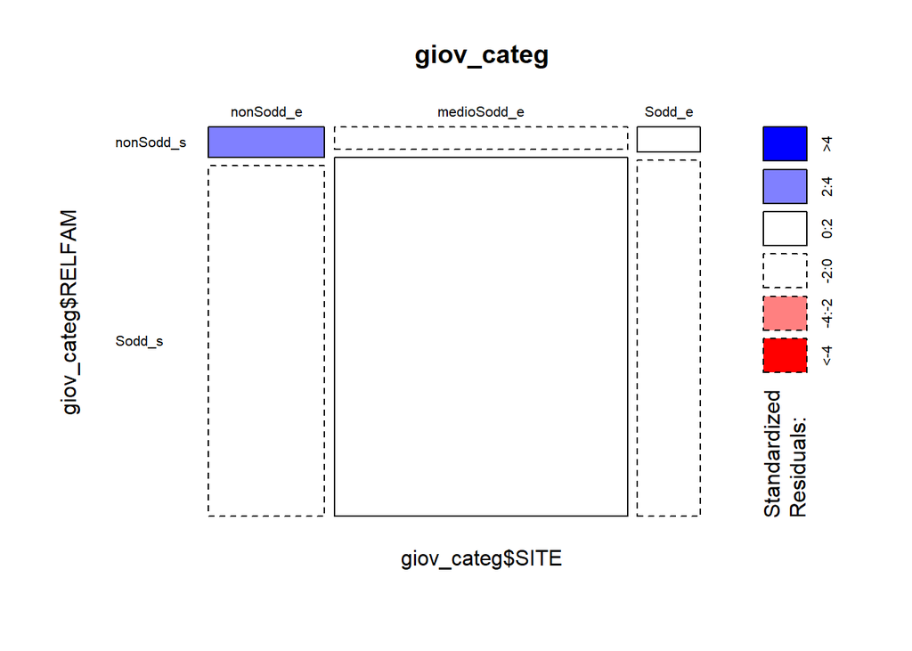

```r
mosaicplot(~giov_categ$SITE+ giov_categ$RELFAM, data=giov_categ,  shade=TRUE, color=TRUE,las=1)
```

#### iii) association between familiar economic situation and satisfaction for spare time, in last 12 months

```r
freq_site_temlib<-table(giov_categ$TEMLIB,giov_categ$SITE)

# contingency table TEMPLIB and SITE
freq_site_temlib
```

```
##
##             nonSodd_e medioSodd_e Sodd_e
##   nonSodd_s       334         728    152
##   Sodd_s          865        2300    499
```

```r
# chi-squared
chiq<-chisq.test(freq_site_temlib)
chiq$expected
```

```
##
##             nonSodd_e medioSodd_e  Sodd_e
##   nonSodd_s  298.3981    753.5859 162.016
##   Sodd_s     900.6019   2274.4141 488.984
```

```r
# print chi-squared
chiq
```

```
##
##  Pearson's Chi-squared test
##
## data:  freq_site_temlib
## X-squared = 7.6359, df = 2, p-value = 0.02197
```

```r
# calculate Cramer
ass<-assocstats(freq_site_temlib)

# print Cramer
ass$cramer
```

```
## [1] 0.0395649
```

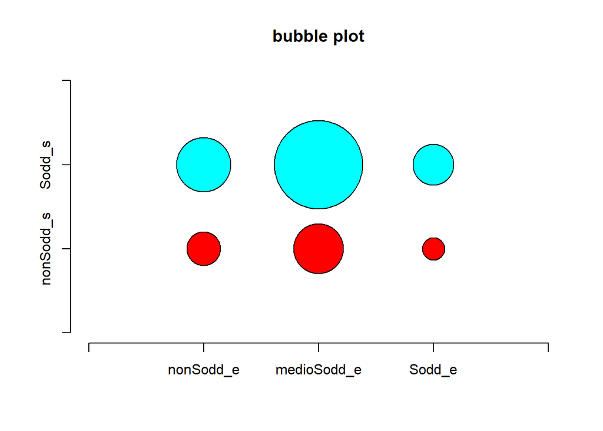

```r
# bubble plot
bubbleplot(freq_site_temlib)
```

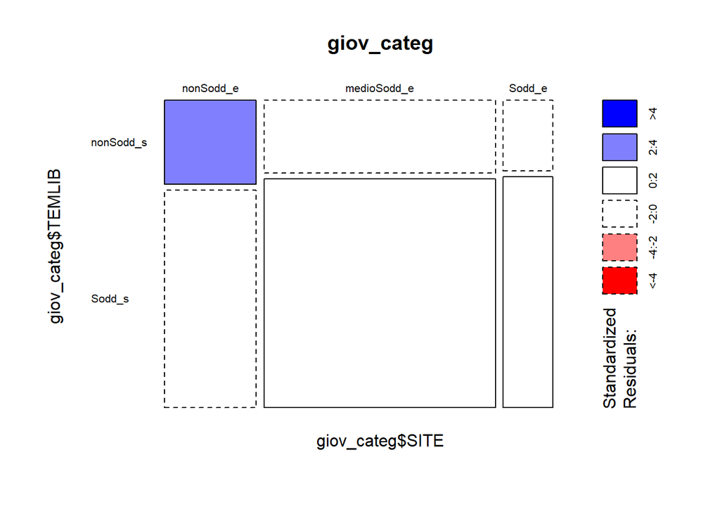

```r
# mosaicplot
mosaicplot(~giov_categ$SITE+ giov_categ$TEMLIB, data=giov_categ,  shade=TRUE, color=TRUE,las=1)
```

The contingency tables, the Chi-square test and the Cramer index show that there is an insignificant statistical association between leisure satisfaction (with reference to the last 12 months) and family economic satisfaction assessed with respect to last year. The confirmation of the correctness of the analysis carried out derives from the mosaic plot which for the category of qualified young people (graduates and high school diploma) shows a low degree of positive association between dissatisfaction with the free time available and dissatisfaction with the family economic situation compared to that of the previous year.

#### b) bivariate analysis: socio-demographic data and satisfaction with economic sustainability

##### i) Association between age and satisfaction for economic situation, in last 12 months

```r
freq_etami_sitec<-table(giov_categ$ETAMi,giov_categ$SITEC)

# print contingency table ETAMi and SITEC
freq_etami_sitec
```

```
##
##         nonSodd_e Sodd_e
##   20-24       730    891
##   25-34      1498   1759
```

```r
# chi-squared
chiq<-chisq.test(freq_etami_sitec)

# print contingency table
chiq$expected
```

```
##
##         nonSodd_e    Sodd_e
##   20-24  740.3829  880.6171
##   25-34 1487.6171 1769.3829
```

```r
# print chi-squared
chiq
```

```
##
##  Pearson's Chi-squared test with Yates' continuity correction
##
## data:  freq_etami_sitec
## X-squared = 0.36369, df = 1, p-value = 0.5465
```

```r
# calculate Cramer
ass<-assocstats(freq_etami_sitec)

# print Cramer
ass$cramer
```

```
## [1] 0.009071548
```

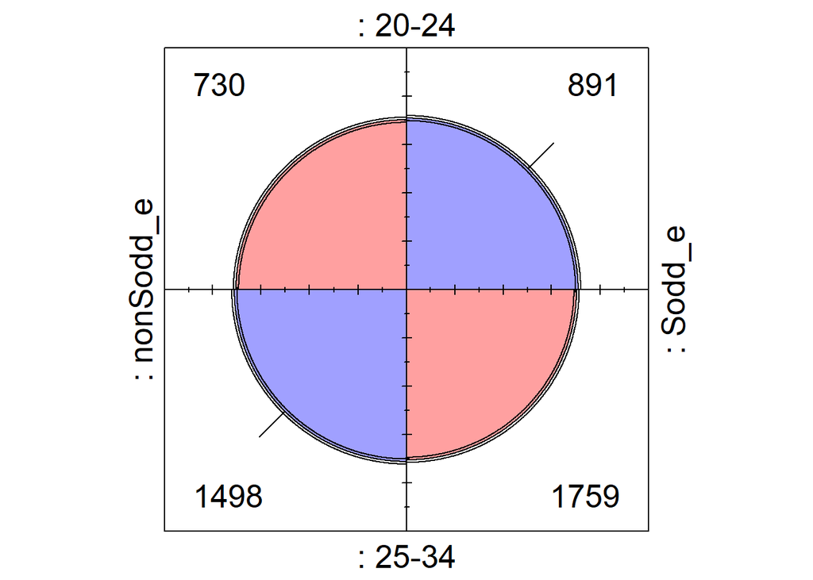

```r
# visualize fourfold
fourfold(freq_etami_sitec)
```

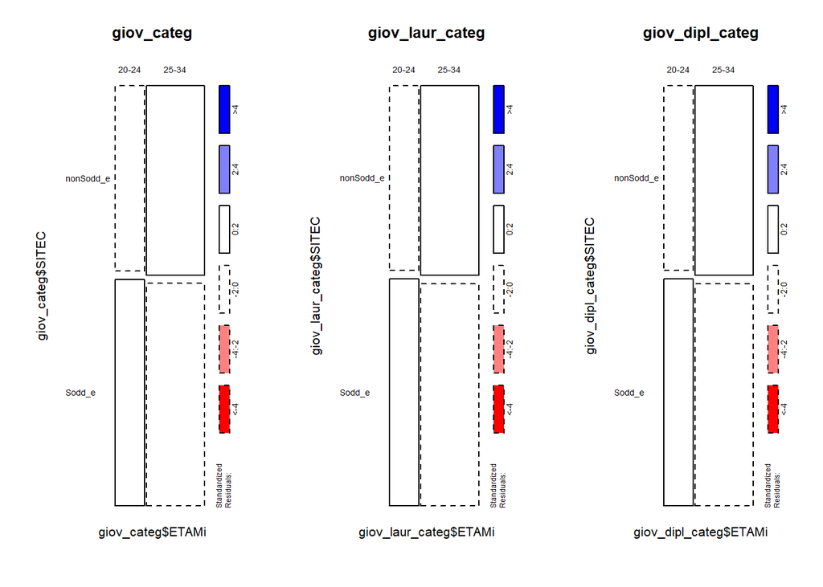

```r
par(mfrow=c(1,3))

#mosaicoplot ETAMi and SITEC
mosaicplot(~giov_categ$ETAMi+ giov_categ$SITEC, data=giov_categ,  shade=TRUE, color=TRUE,las=1)
#mosaicoplot ETAMi and SITEC
mosaicplot(~giov_laur_categ$ETAMi+ giov_laur_categ$SITEC, data=giov_laur_categ,  shade=TRUE, color=TRUE,las=1)
#mosaicoplot ETAMi and SITEC
mosaicplot(~giov_dipl_categ$ETAMi+ giov_dipl_categ$SITEC, data=giov_dipl_categ,  shade=TRUE, color=TRUE,las=1)
```

In analysis of the graphs illustrated, it is clear that there is no connection between the variables *“satisfaction with the economic situation in the last 12 months”* and *“age”*.

##### ii) Association between gender and economic situation, in last 12 months

```r
freq_sesso_sitec<-table(giov_categ$SESSO,giov_categ$SITEC)

freq_sesso_sitec
```

```
##
##          nonSodd_e Sodd_e
##   male        1066   1348
##   female      1162   1302
```

```r
chiq<-chisq.test(freq_sesso_sitec)

chiq$expected
```

```
##
##          nonSodd_e   Sodd_e
##   male    1102.581 1311.419
##   female  1125.419 1338.581
```

```r
chiq
```

```
##
##  Pearson's Chi-squared test with Yates' continuity correction
##
## data:  freq_sesso_sitec
## X-squared = 4.3028, df = 1, p-value = 0.03805
```

```r
ass<-assocstats(freq_sesso_sitec)

ass$cramer
```

```
## [1] 0.0301115
```

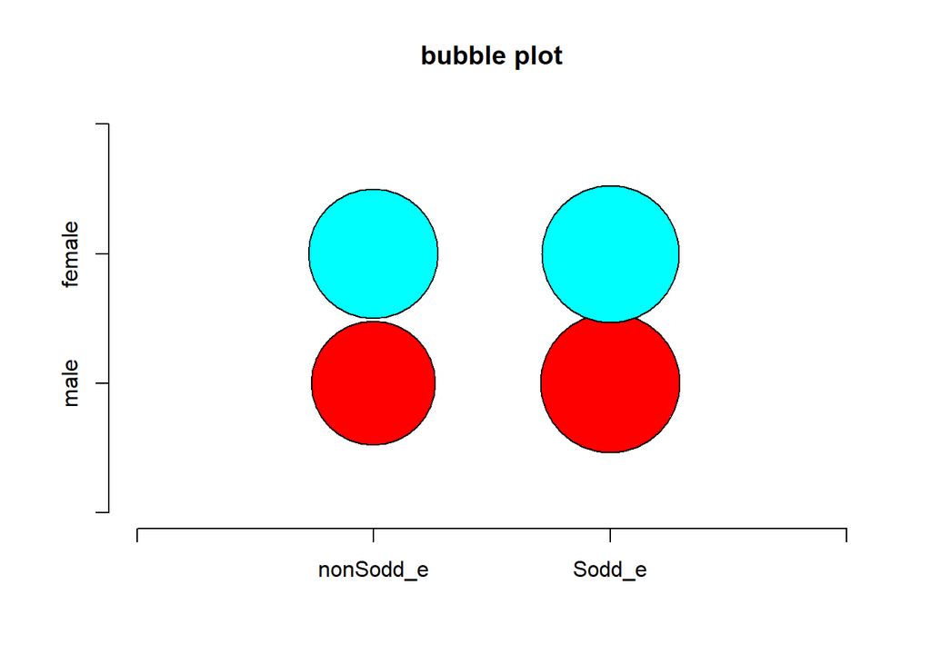

```r
bubbleplot(freq_sesso_sitec)
```

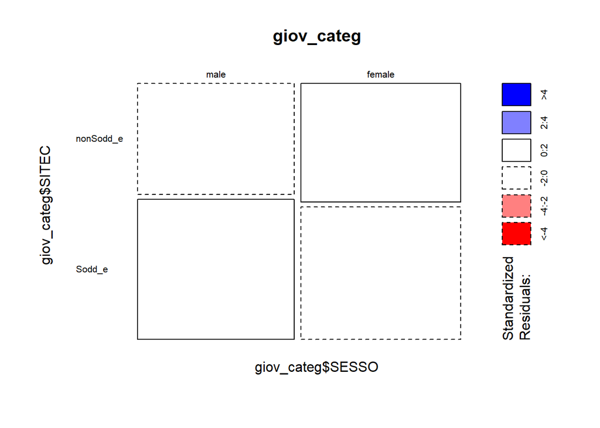

```r
mosaicplot(~giov_categ$SESSO+ giov_categ$SITEC, data=giov_categ,  shade=TRUE, color=TRUE,las=1)
```

#### c) bivariate analysis: associations between the variables of economic sustainability

#### i) association between satisfaction with the economic situation in the last 12 months and evaluation of the family’s economic situation compared with that of a year ago

```r
freq_site_sitec<-table(giov_categ$SITE,giov_categ$SITEC)

freq_site_sitec
```

```
##
##               nonSodd_e Sodd_e
##   nonSodd_e         827    372
##   medioSodd_e      1248   1780
##   Sodd_e            153    498
```

```r
chiq<-chisq.test(freq_site_sitec)

chiq$expected
```

```
##
##               nonSodd_e    Sodd_e
##   nonSodd_e    547.6367  651.3633
##   medioSodd_e 1383.0226 1644.9774
##   Sodd_e       297.3407  353.6593
```

```r
chiq
```

```
##
##  Pearson's Chi-squared test
##
## data:  freq_site_sitec
## X-squared = 415.57, df = 2, p-value < 2.2e-16
```

```r
ass<-assocstats(freq_site_sitec)

ass$cramer
```

```
## [1] 0.291878
```

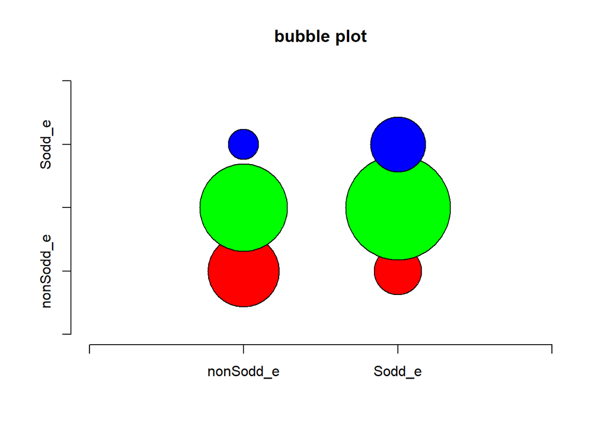

```r
bubbleplot(freq_site_sitec)
```

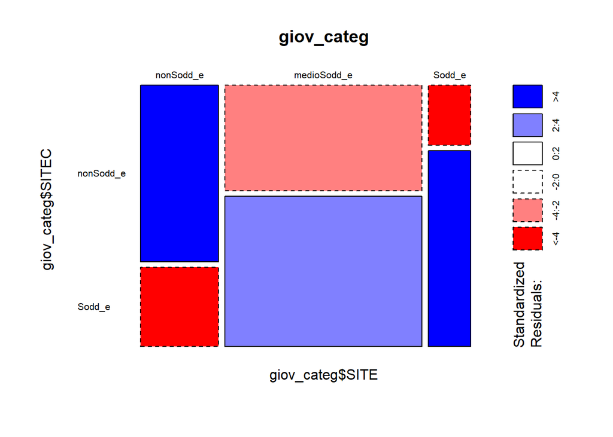

```r
freql_site_sitec<-table(giov_laur_categ$SITE,giov_laur_categ$SITEC)
freqd_site_sitec<-table(giov_dipl_categ$SITE,giov_dipl_categ$SITEC)
mosaicplot(~giov_categ$SITE+ giov_categ$SITEC, data=giov_categ,  shade=TRUE, color=TRUE,las=1)
```

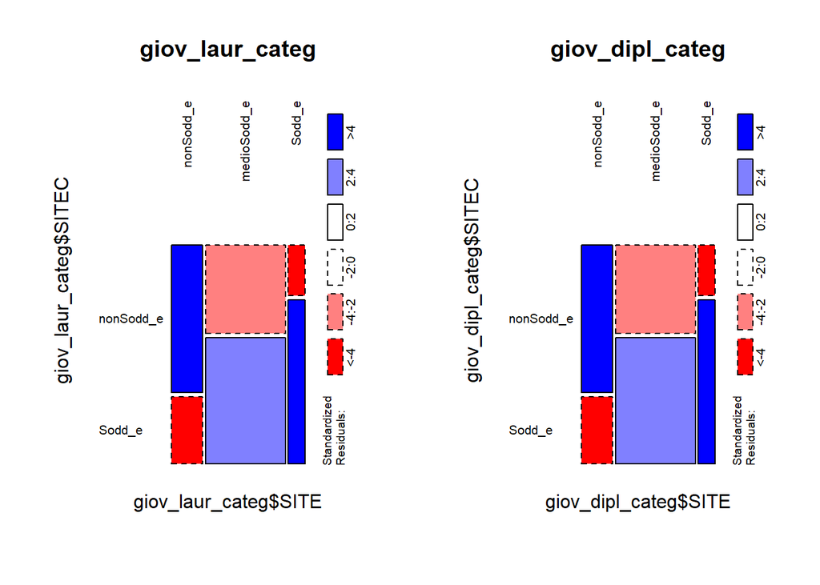

```r
par(mfcol=c(1,2))
mosaicplot(~giov_laur_categ$SITE+ giov_laur_categ$SITEC, data=giov_laur_categ,  shade=TRUE, color=TRUE,las=2)
mosaicplot(~giov_dipl_categ$SITE+ giov_dipl_categ$SITEC, data=giov_dipl_categ,shade=T,las=2)
```

The mosaic plots illustrate how there is a significant (medium-high) association between the variables “satisfaction with the economic situation in the last 12 months” and “family economic situation compared to that of a year ago”. In particular, there is a more marked intensity between dissatisfied (of both variables compared) and satisfied (always indicated in the same way), compared to those who indicated dissatisfaction with one variable and satisfaction with the other. The graph relating to the category of graduates follows the same trend as that of graduates, adding a slight association between the variables with the modalities of average satisfaction.

### Chapter 3: Multivariate analysis

In this section we will analyze the active variables under study, through the method of multiple correspondence analysis. The objective, therefore, is to analyze the relationships existing between the set of variables concerning the category *economic satisfaction* (SITEC, SITE and RISEC) and the category *social satisfaction* (RELFAM, RELAM, TEMLIB, FUTUASP) observed in the collective.

#### 3.1 Multiple correspondence analysis

```r
library(ggplot2)
library(ca)
dataset_acm<- giov_laur_categ[, 6:12]
mca = mjca(dataset_acm) # ACM sulla Burt matrix
summary(mca)
```

```
##
## Principal inertias (eigenvalues):
##
##  dim    value      %   cum%   scree plot
##  1      0.024891  63.1  63.1  *********************
##  2      0.005085  12.9  76.0  ****
##  3      0.000258   0.7  76.7
##  4      1e-06000   0.0  76.7
##         -------- -----
##  Total: 0.039431
##
##
## Columns:
##                           name   mass  qlt  inr    k=1  cor ctr    k=2 cor ctr
## 1  |           SITEC:nonSodd_e |   65  872   60 |  216  856 124 |   30  16  12
```

[output cut: 34 more lines]

```r
mca
```

```
##
##  Eigenvalues:
##            1        2        3        4
## Value      0.024891 0.005085 0.000258 1e-06
## Percentage 63.13%   12.9%    0.65%    0%
##
##
##  Columns:
##         SITEC:nonSodd_e SITEC:Sodd_e SITE:nonSodd_e SITE:medioSodd_e
## Mass           0.065285     0.077650       0.035139         0.088820
## ChiDist        0.466432     0.392267       0.758419         0.311441
## Inertia        0.014203     0.011948       0.020212         0.008615
## Dim. 1         1.375618    -1.158420       1.976673        -0.484907
## Dim. 2         0.420979    -0.358590       1.770319        -0.348529
##         SITE:Sodd_e RISEC:nonSodd_e RISEC:Sodd_e RELFAM:nonSodd_s RELFAM:Sodd_s
## Mass       0.018944        0.049073     0.093858         0.009273      0.133583
## ChiDist    1.010312        0.612565     0.319299         1.540300      0.106850
## Inertia    0.019336        0.018414     0.009569         0.022001      0.001525
## Dim. 1    -1.395442        1.738267    -0.910602         2.821592     -0.196585
## Dim. 2    -1.644948        1.350925    -0.702708        -4.499636      0.309985
##         RELAM:nonSodd_s RELAM:Sodd_s TEMLIB:nonSodd_s TEMLIB:Sodd_s
## Mass           0.013189     0.129688         0.035648      0.107180
## ChiDist        1.302785     0.132654         0.710936      0.236393
## Inertia        0.022386     0.002282         0.018018      0.005989
## Dim. 1         2.466298    -0.251763         1.480356     -0.494203
## Dim. 2        -4.523003     0.459046        -1.897467      0.629573
##         FUTUASP:non so FUTUASP:peggiorera FUTUASP:restera la stessa
## Mass          0.026888           0.004347                  0.024524
## ChiDist       0.797247           2.186836                  0.835723
## Inertia       0.017090           0.020787                  0.017129
## Dim. 1        0.753471           3.352179                  0.065900
## Dim. 2       -0.030841          -0.419120                  0.195091
##         FUTUASP:migliorera
## Mass              0.086911
## ChiDist           0.310665
## Inertia           0.008388
## Dim. 1           -0.417285
## Dim. 2           -0.029558
```

```r
library("FactoMineR")
library("factoextra")
```

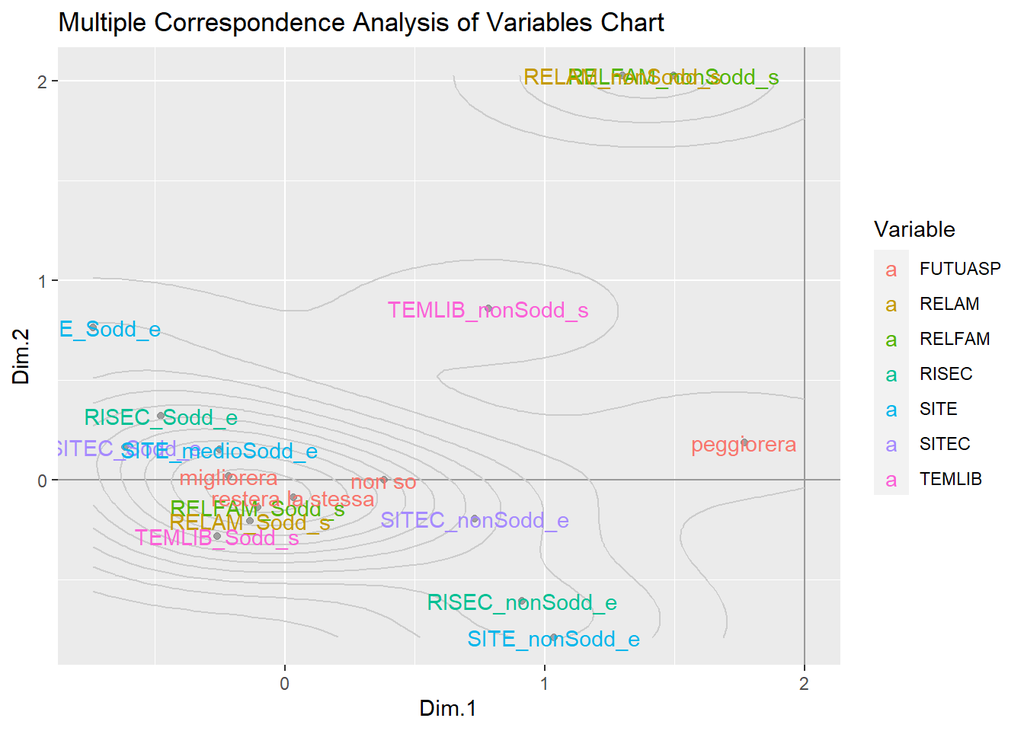

```r
dat <- na.omit(giov_laur_categ[,6:12])
# number of categories per variable
cats = apply(dat, 2, function(x) nlevels(as.factor(x)))

mca1 = MCA(dat, graph = FALSE)
acm = data.frame(mca1$var$coord, Variable = rep(names(cats), cats))

# MCA plot of observations and categories
ggplot(data = acm, aes(x = Dim.1, y = Dim.2)) +
  geom_hline(yintercept = 0, colour = "gray60") +
  geom_vline(xintercept = 2, colour = "gray60") +
  geom_point(colour = "gray50", alpha = 0.7) +
  geom_density2d(colour = "gray80") +
  geom_text(data = acm,
            aes(x = Dim.1, y = Dim.2,
                label = rownames(acm), colour = Variable)) +
  ggtitle("Multiple Correspondence Analysis of Variables Chart") +
  scale_colour_discrete(name = "Variable")
```

The analysis of the multiple correspondences illustrates how there is a strong association between the satisfied of the **social** category with the **economic** one. The graph also illustrates an association between dissatisfied with family relationships and dissatisfied with friendships; the same result also applies to the economic category, where those who are dissatisfied with their own economic situation are associated with family economic dissatisfaction. However, there is no association between those who are dissatisfied with their economic situation and those who are dissatisfied with the social dimension.

```r
# denine active variables
avq.active<-giov_laur_categ[,c(6:12)]

# delete missing values
avq.active_2<- na.omit(avq.active)

# frequence analysis of active variables
summary(avq.active_2)
```

```
##        SITEC               SITE            RISEC            RELFAM
##  nonSodd_e:2228   nonSodd_e  :1199   nonSodd_e:1672   nonSodd_s: 316
##  Sodd_e   :2650   medioSodd_e:3028   Sodd_e   :3206   Sodd_s   :4562
##                   Sodd_e     : 651
##
##        RELAM            TEMLIB                  FUTUASP
##  nonSodd_s: 452   nonSodd_s:1214   non so           : 917
##  Sodd_s   :4426   Sodd_s   :3664   peggiorera       : 150
##                                    restera la stessa: 838
##                                    migliorera       :2973
```

```r
# load libraries for multiple correspondence analysis
library("FactoMineR")
library("factoextra")

# multiple correspondence analysis active variables
res.mca <- MCA(avq.active_2, graph = FALSE) #ACM
#print(res.mca)

# print factorial axes
eigen<- get_eigenvalue(res.mca)
eigen
```

```
##        eigenvalue variance.percent cumulative.variance.percent
## Dim.1  0.27731338        19.411936                    19.41194
## Dim.2  0.20306417        14.214492                    33.62643
## Dim.3  0.15585860        10.910102                    44.53653
## Dim.4  0.14291280        10.003896                    54.54043
## Dim.5  0.13630209         9.541146                    64.08157
## Dim.6  0.12792944         8.955061                    73.03663
## Dim.7  0.11785796         8.250057                    81.28669
## Dim.8  0.09950759         6.965531                    88.25222
## Dim.9  0.09094745         6.366322                    94.61854
## Dim.10 0.07687794         5.381456                   100.00000
```

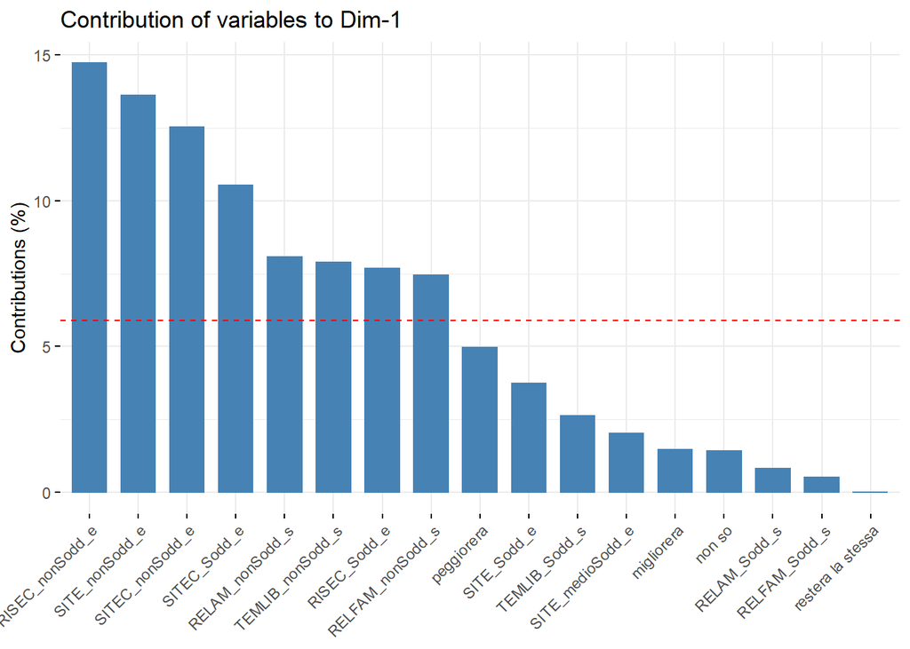

```r
fviz_contrib(res.mca, choice="var", axes= 1)
```

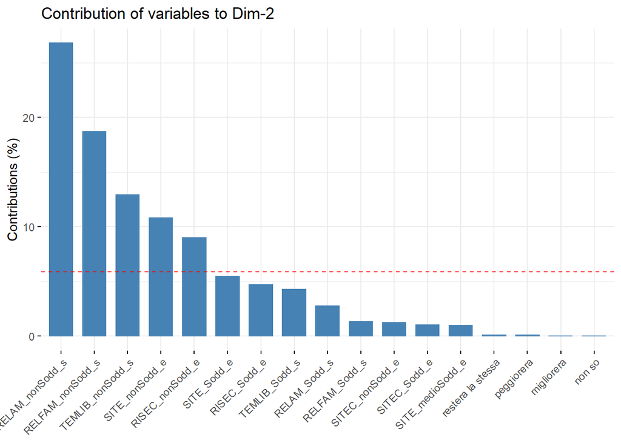

```r
fviz_contrib(res.mca, choice="var", axes= 2)
```

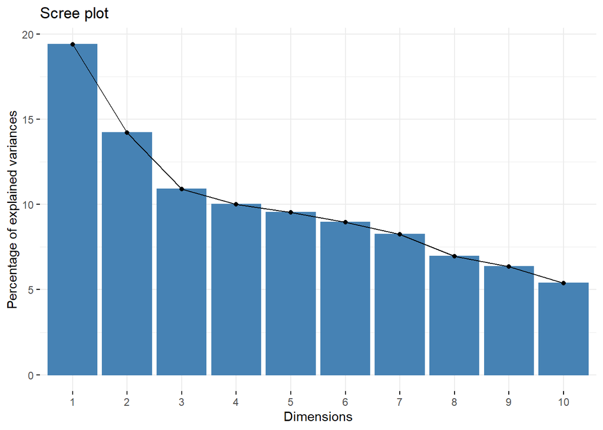

```r
# scree plot
fviz_screeplot(res.mca)
```

The analysis shows that the most significant dimensions include **economic dissatisfaction** (dimension 1) and **social dissatisfaction** (dimension 2), together explaining about 34% of the total inertia.

#### 3.2 Clustering

```r
giov_laur_ita_categ<-giov_laur_categ

head(giov_laur_ita_categ,10)
```

```
##    ETAMi  SESSO   ISTRMi    REGMF      RIPMF     SITEC        SITE     RISEC
## 3  20-24   male  diploma  liguria north-west nonSodd_e medioSodd_e    Sodd_e
## 14 25-34 female graduate  liguria north-west    Sodd_e medioSodd_e    Sodd_e
## 18 20-24   male  diploma  liguria north-west    Sodd_e medioSodd_e    Sodd_e
## 19 20-24 female graduate  liguria north-west    Sodd_e medioSodd_e    Sodd_e
## 27 25-34 female graduate  liguria north-west nonSodd_e medioSodd_e    Sodd_e
## 48 25-34   male graduate  toscana     center nonSodd_e medioSodd_e    Sodd_e
## 53 25-34 female  diploma  toscana     center nonSodd_e   nonSodd_e nonSodd_e
## 54 25-34 female  diploma  toscana     center nonSodd_e   nonSodd_e nonSodd_e
## 68 25-34 female graduate  toscana     center nonSodd_e medioSodd_e    Sodd_e
## 89 20-24 female  diploma campania      south    Sodd_e medioSodd_e    Sodd_e
##       RELFAM     RELAM    TEMLIB           FUTUASP
## 3  nonSodd_s nonSodd_s nonSodd_s restera la stessa
## 14    Sodd_s    Sodd_s    Sodd_s              <NA>
## 18    Sodd_s    Sodd_s    Sodd_s        migliorera
## 19    Sodd_s    Sodd_s    Sodd_s        migliorera
## 27    Sodd_s    Sodd_s    Sodd_s            non so
## 48    Sodd_s    Sodd_s    Sodd_s        migliorera
## 53    Sodd_s nonSodd_s    Sodd_s        migliorera
## 54    Sodd_s    Sodd_s    Sodd_s        migliorera
## 68    Sodd_s    Sodd_s nonSodd_s restera la stessa
## 89    Sodd_s    Sodd_s    Sodd_s        migliorera
```

```r
# definisco le variabili attive per giovani nel lazio
avq.active<- na.omit(giov_laur_ita_categ[, 6:12])
head(avq.active,10)
```

```
##        SITEC        SITE     RISEC    RELFAM     RELAM    TEMLIB
## 3  nonSodd_e medioSodd_e    Sodd_e nonSodd_s nonSodd_s nonSodd_s
## 18    Sodd_e medioSodd_e    Sodd_e    Sodd_s    Sodd_s    Sodd_s
## 19    Sodd_e medioSodd_e    Sodd_e    Sodd_s    Sodd_s    Sodd_s
## 27 nonSodd_e medioSodd_e    Sodd_e    Sodd_s    Sodd_s    Sodd_s
## 48 nonSodd_e medioSodd_e    Sodd_e    Sodd_s    Sodd_s    Sodd_s
## 53 nonSodd_e   nonSodd_e nonSodd_e    Sodd_s nonSodd_s    Sodd_s
## 54 nonSodd_e   nonSodd_e nonSodd_e    Sodd_s    Sodd_s    Sodd_s
## 68 nonSodd_e medioSodd_e    Sodd_e    Sodd_s    Sodd_s nonSodd_s
## 89    Sodd_e medioSodd_e    Sodd_e    Sodd_s    Sodd_s    Sodd_s
## 99    Sodd_e medioSodd_e    Sodd_e    Sodd_s    Sodd_s    Sodd_s
##              FUTUASP
## 3  restera la stessa
## 18        migliorera
## 19        migliorera
## 27            non so
## 48        migliorera
## 53        migliorera
## 54        migliorera
## 68 restera la stessa
## 89        migliorera
## 99        migliorera
```

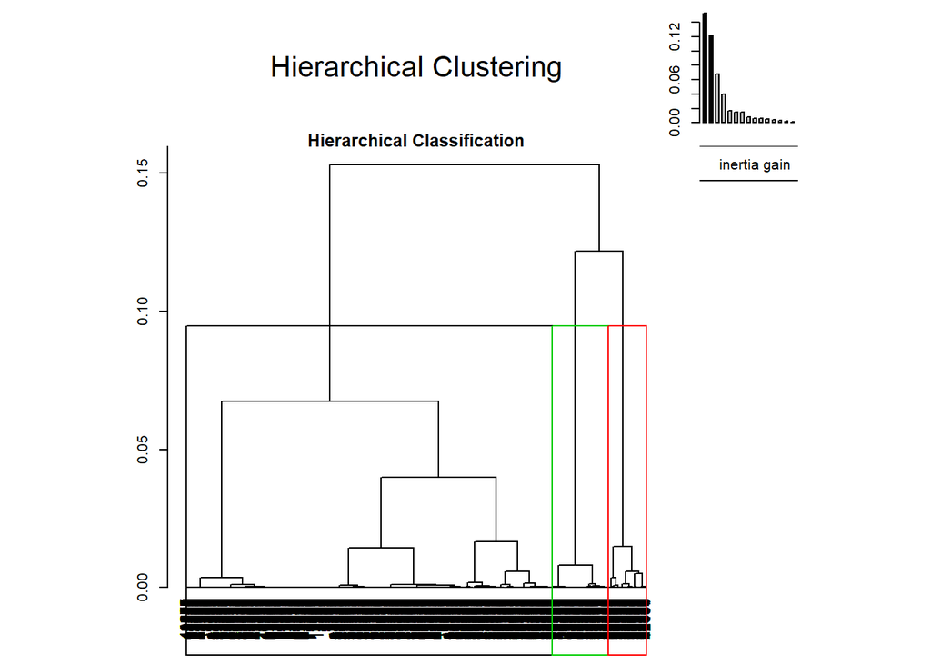

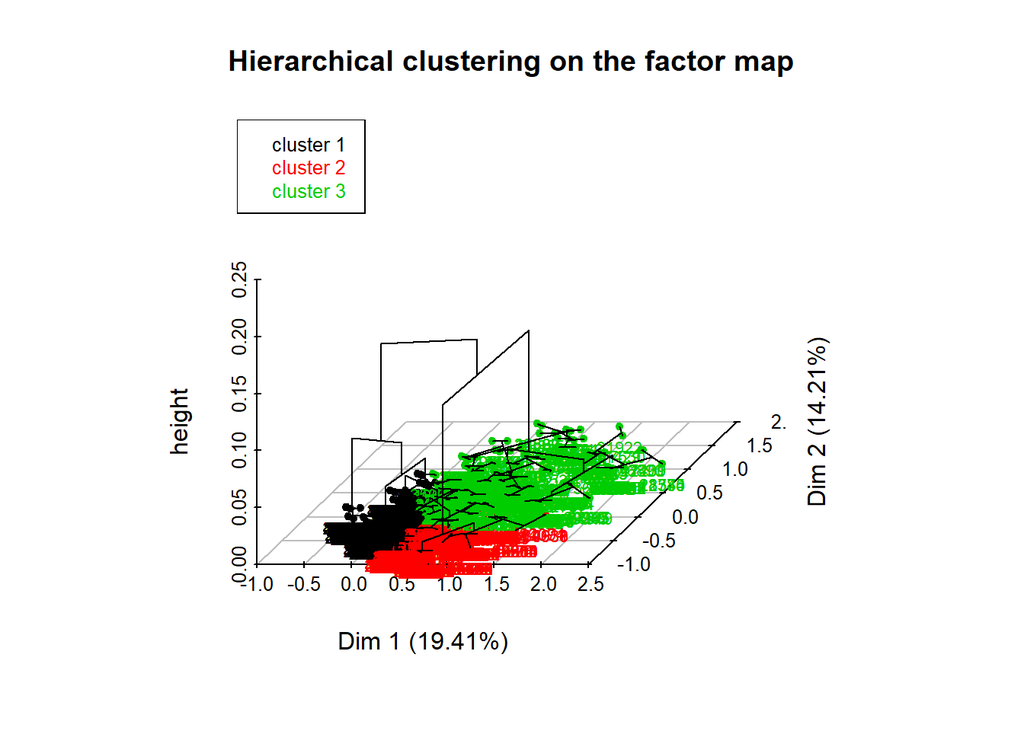

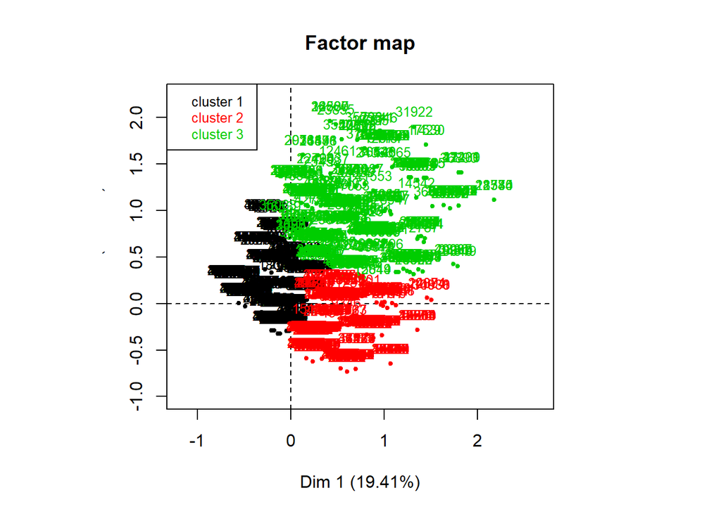

```r
# analysis multiple correspondence
# ncp: number of dimensions
res2.mca <- MCA(avq.active, ncp = 2, graph = FALSE)

# cluster analysis
res.hcpc <- HCPC(res2.mca, nb.clust = -1, graph = TRUE)
```

#### Conclusions

[^1]: E. Durkheim in *“The rules of sociological method”* argues that social facts *consist of ways of acting, thinking and feeling, external to the individual, and which endowed with a power of coercion by virtue of which they impose themselves on him*
[^2]: N. Mazzoleni, *“Fuga di cervelli. Un fenomeno statistico e sociologico raccontato da Alessandro Rosina”*,“Artribune”, 11 November 2013
[^3]: Il Fatto Quotidiano, *“Istat, more and more Italians are moving abroad: 53% have a high school diploma or degree. For the first time, migrants from Africa drop: -17%”* “Il Fatto Quotidiano”*, 16 December 2019, at the following link link: https://www.ilfattoquotidiano.it/2019/12/16/istat-sempre-piu-italiani-si-trasferiscono-allestero-il-53-di-chi-e-partito-nel-2018-e-diplomato-o-laureato-calano-i-migranti-dallafrica-17/5619619/